# Comparsion of methods on multiomics integration [CITE-seq datasets]

jinzhuang dou @ kenchen’lab in MDACC

March 7, 2021

This guide will show the perfomance of methods (bindSC, Seurat, LIGER, and Harmony) on integrating scRNA and protein data. Download dataset from https://drive.google.com/file/d/1CgL_WUXIU9a0IsYelk-9niky2wr5aaOT/view?usp=sharing and change the input to your own file path.

#### Stage 1: load CITE-seq datasets

```r
library(bindSC)
source("./runMethod.R")
source("./Eval.R")
library(Seurat)
library(peakRAM)

bm <- readRDS(file="../../data/cite_seq.RDS")
summary(bm)
dim(bm$RNA)
dim(bm$Protein)
dim(bm$Z)
tp <- colSums(bm$Z)
cell_sel <- which(tp>2)
N <- length(cell_sel)
y <- bm$RNA[, cell_sel]
x <- bm$Protein[, cell_sel]
z0 <- bm$Z[,cell_sel]
dim(x)
dim(y)
dim(z0)
x.clst <- bm$meta$celltype2[cell_sel]
y.clst <- bm$meta$celltype2[cell_sel]


X <- x
Z0 <-  z0

celltype <- c(as.character(x.clst), as.character(y.clst))


rd_time <- c()
rd_mem <- c()
```

#### Stage 2: run four methods

Run bindSC. The time used is also shown.

```r
out <- peakRAM(
  bindsc <- BiCCA( X = x ,
             Y = y,
             Z0 =z0,
             X.clst = x.clst,
             Y.clst = y.clst,
             alpha = 0.1,
             lambda = 0.7,
             K = 15,
             temp.path  = "out",
             num.iteration = 50,
             tolerance = 0.01,
             save = TRUE,
             parameter.optimize = FALSE,
             block.size = 0)

)


rd_mem <- c(rd_mem, out$Peak_RAM_Used_MiB)
rd_time <- c(rd_time, out$Elapsed_Time_sec)


bindsc_umap <- get_UMAP(rbind(bindsc$u, bindsc$r))
```

Run Seurat. The time used is also shown.

```r
memory_start <- sum(.Internal(gc(FALSE, TRUE, TRUE))[13:14])
time_start <- Sys.time()


out<-peakRAM(seurat <- runSeurat(X = X, Z0=Z0, K = 15))

memory_end <- sum(.Internal(gc(FALSE, TRUE, TRUE))[13:14])
time_end <- Sys.time()
memory_usage <- memory_end - memory_start
time_usage <- time_end - time_start


rd_mem <- c(rd_mem, out$Peak_RAM_Used_MiB)
rd_time <- c(rd_time, out$Elapsed_Time_sec)

seurat_umap <- get_UMAP(seurat)
```

Run LIGER. The time used is also shown.

```r
out<-peakRAM(liger <- runLIGER(X = X, Z0=Z0, K = 15))


rd_mem <- c(rd_mem, out$Peak_RAM_Used_MiB)
rd_time <- c(rd_time, out$Elapsed_Time_sec)

liger_umap <- get_UMAP(liger)
```

Run Harmony. The time used is also shown.

```r
out<-peakRAM(harmony <- runHarmony(X = X, Z0=Z0, K = 15))



rd_mem <- c(rd_mem, out$Peak_RAM_Used_MiB)
rd_time <- c(rd_time, out$Elapsed_Time_sec)

harmony_umap <- get_UMAP(harmony)
```

#### Stage 3: Visulization of integration for each method.

UMAP shows results from co-embeddings of each method, split by different modalites. For convenience, the cells are colored by annotation from co-assyed profiles. This means that the color is consistent between two modalites

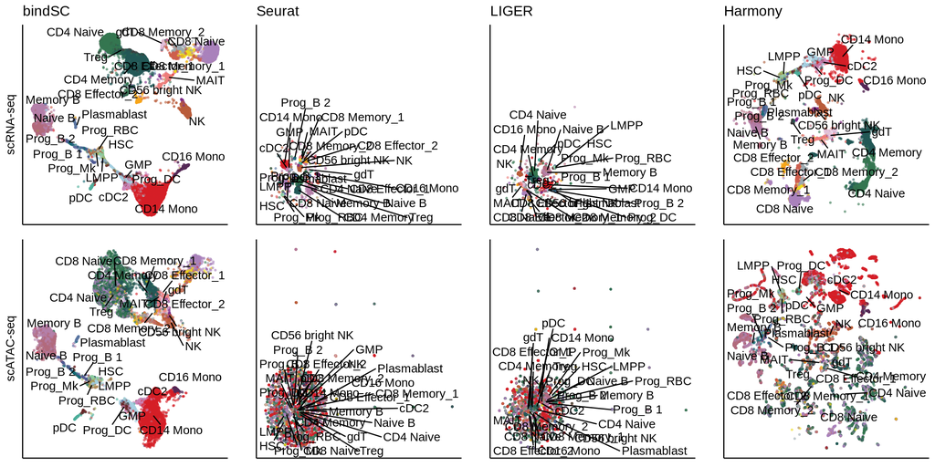

```r
source("./Eval.R")
tp <- rbind(bindsc_umap, seurat_umap, liger_umap,  harmony_umap)
merged_dt <- data.frame("UMAP1"=tp[,1], "UMAP2"=tp[,2],
                        "celltype"=rep(as.factor(celltype),4),
                        tech=rep(c(rep("A",ncol(X)), rep("B",ncol(Z0))),4),
                        "method"=c(rep("bindSC", nrow(bindsc_umap)),
                                   rep("Seurat", nrow(seurat_umap)),
                                   rep("LIGER",  nrow(liger_umap)),
                                   rep("Harmony", nrow(harmony_umap))))
#pos <- !((merged_dt$UMAP1>20 | merged_dt$UMAP2>20) & merged_dt$method=="bindSC")
p <- umapPlot(merged_dt = merged_dt, tech_label = c("scRNA-seq","scATAC-seq"))

p
```

#### Stage 4: Visulization of integration accuracy.

We use three indexs: 1) silhouette score; 2) alignment mixing score; 3) anchoring distance. Higher silhoouette score means cell type are well separated in the co-embedding space. Higher alignment mixing score means two modalites are aligned well in the co-embedding space. Lower Anchoring distance means the cell with measurement from two modalites is closer in the co-embedding space.

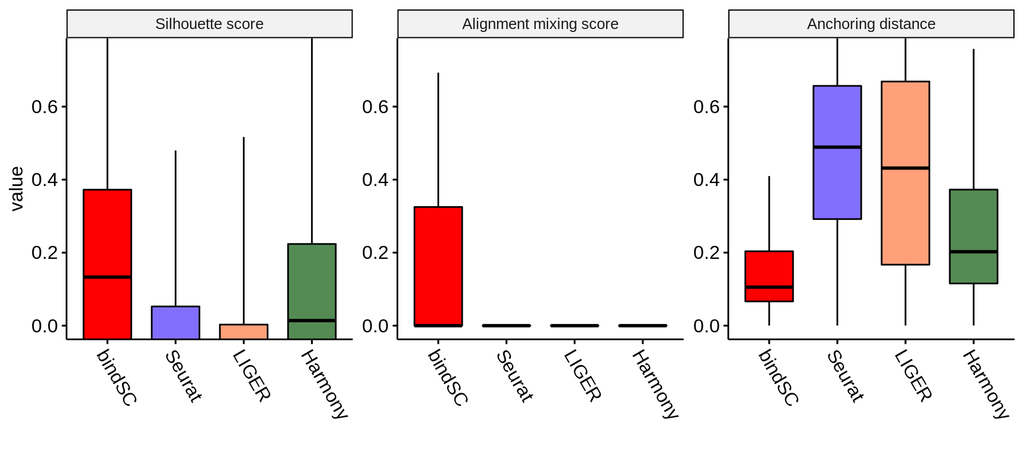

```r
coembed <- rbind(rbind(bindsc$u, bindsc$r),seurat, liger, harmony)
out <- alignmentScore(coembed = merged_dt[,c("UMAP1","UMAP2")], merged_dt = merged_dt)
# No meaniful results are obtained using original coembeddings. Thus we use coordinates of 2d-UMAP for evaluaiton
#out <- alignmentScore(coembed = coembed, merged_dt = merged_dt)
p <- score_plot(out)
print(p)
```

#### Stage 5: Running time and memory usage

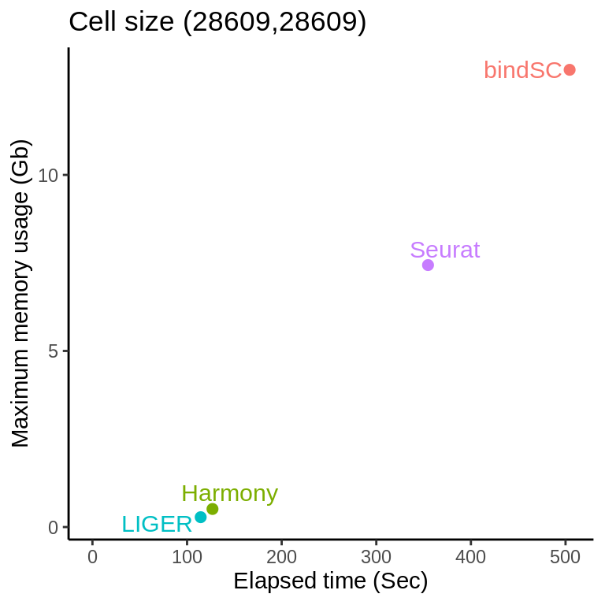

```r
# Use Gb

cpu_time <- data.frame("Time"=rd_time,"Memory"=rd_mem,"Method"=c("bindSC","Seurat","LIGER","Harmony"))
cpu_time$Memory <- cpu_time$Memory/1024
p <- ggscatter(cpu_time,x="Time", y="Memory", color="Method",label="Method", repel = TRUE)  +
  theme_classic() + NoLegend() + xlim(0, max(cpu_time$Time))+
  xlab("Elapsed time (Sec)") + ylab("Maximum memory usage (Gb)") + ggtitle(paste0("Cell size (", length(x.clst),",", length(y.clst),")" ))
p
```

```r
saveRDS(cpu_time,file="./citeseq.cpu_usage.RDS")
```

#### Stage 6: Save resutls

```r
result <- list()
result$coembed <- coembed
result$umap <- merged_dt
result$score <- out
saveRDS(result, file="citeseq.methodEval.RDS")
```